# Scottish Stroke Statistics Report

[figure not shown]

```r
# function and colour palettes

`%!in%` <- negate(`%in%`)

pal <- c("Male" = "#a6bddb", "Female" = "#fa9fb5")

nhs <- c( "#ee9c00", "#ff0000",
         "#b80068", "#00a15f",
         "#0391bf", "#67bf29", "#00684d")

hb <- c('#a6cee3','#1f78b4','#b2df8a',
         '#33a02c','#fb9a99','#e31a1c',
         '#fdbf6f','#ff7f00','#cab2d6',
         '#6a3d9a','#525252')
```

# 1 Background

Cerebrovascular disease develops as a result of problems with the blood vessels supplying oxygen rich blood to the brain. Scotland has a high prevalence of the risk factors associated with cerebrovascular disease such as smoking and high blood pressure. Despite a substantial decrease in rates of death over the last decade, treating and preventing stroke is a national clinical priority for Scotland as outlined in the Stroke Improvement Plan. The Information Services Division (now PHS) provides an annual update on cerebrovascular disease in Scotland, including stroke, brain haemorrhage and ‘mini-stroke’

## 1.1 Business intelligence and data-driven decision making

Public Health Scotland (PHS) and NHS Scotland can gain insights in the demand in service across Scotland and the local health boards. Anomaly high/low spikes in diagnoses or mortality rates when compared to the average like crude rate can warn of local factors that need adressing/chances of false negative diagnoses.

## 1.2 Domain knowledge and the business context

Public Health Scotland (PHS) “vision is for a Scotland where everybody thrives. Focusing on prevention and early intervention, we aim to increase healthy life expectancy and reduce premature mortality by responding to the wider determinants that impact on people’s health and wellbeing.”

PHS provides an annual update on cerebrovascular disease in Scotland, including stroke, brain haemorrhage and ‘mini-stroke’. The data is compiled from NHS Scotland from the local health boards and local authority.

# 2 Data

## 2.1 Internal and external data sources

All the data came from PHS, 3 that covered the diagnoses or mortality rates for the health boards and local authority where supplied from CodeClan as part of the project brief. I sourced the codes and labels csv from the PHS website.

## 2.2 Types of data

The data came in Character and Double class types. Change the Character to Factors for use in models and graph work.

“Chr” an object that holds character strings

“Fctr” Factors refers to categorical variables that have a fixed and known set of possible values.

“Dbl” refers to a data type defined to hold numeric values with decimal points unlike integers that are whole numbers.

## 2.3 Data formats

All data was downloaded as .CSV files

## 2.4 Data quality and bias

Believe that the data was good quality and wasn’t biased. There is some out of date health boards identifier codes that have been replaced used in the diagnoses or mortality rates datasets that will be up-to date if re-pulled from the PHS website. The data has been aggregated to a high level so wasn’t as useful as I’d hoped in making predictive models.

# 3 Ethics

## 3.1 Ethical issues in data sourcing and extraction

I did not have any ethical concerns regarding the sourcing and extraction of this data. The data followed the GDPR frame work, with identifiable and non-required information removed.

## 3.2 Ethical implications of business requirements

I don’t believe that there is any ethical implications from the project requirements, as this data is being used to focusing on prevention and early intervention in people health.

# 4 Analysis

## 4.1 Stages in the data analysis process

Reading in of the data.  
Cleaning the data.  
Understanding the data.  
Visualization of the data. Kitting the data.

## 4.2 Tools for data analysis

Git/GitHub for version control

R packages used:  
tidyverse  
ggplot2  
janitor

## 4.3 Descriptive, diagnostic, predictive and prescriptive analysis

**Descriptive Analytics**  
This project includes data in the time frame from 2009/10 to 2018/19 and is categorise as descriptive analytics. Some of the datasets had the dates as 2009 or 2009/10, changes these dates to 2009 so they were consistent throughout code, in the report and pretension text used 2009/10 to show the data covered the financial years.

**Diagnostic Analytics**  
The data in this time frame shows the diagnostic and mortality rate in Scotland. Used this data to make the graphs and tables used this report. This helps with the understanding of what has been going on within the time frame.

**Predictive Analytics**  
Predicts what is most likely to happen in the future. Unable to give a good model to predicts future trends, with the data being aggregated to a high level

**Prescriptive Analytics**  
Recommended actions from the Diagnostic Analytics.

**Rural Focus**

- Focus on areas with higher mortality proportion to their population: NHS Dumfries & Galloway, Borders and Highland

**Transfer Focus**

- Continue to focus on treatment hubs with higher number of specialist together: NHS Glasgow, Lothian, Lanarkshire and possibly include Grampian

**Gender Focus**

- Focus on preventative measures primarily Female.
- Male patients may have succumbed to other health issues, should be included in preventative measures

**Preventative Age Focus**

- Encourage throughout adulthood: healthy diet, exercise regularly, and avoid smoking and drinking too much alcohol.

# 5 EDA

## 5.1 Reading and cleaning data

```r
council_areas <- read_csv(
  "../raw_data/dz2001_codes_and_labels_21042020.csv") %>%
  clean_names()

hb_stroke <- read_csv("../raw_data/stroke_activitybyhbr.csv") %>%
  clean_names() %>%
  rename(health_board = "hbr")

ca_stroke <- read_csv("../raw_data/stroke_activitybyca.csv") %>%
  clean_names() %>%
  rename(area_codes = "ca")

stroke_mortality_hb <- read_csv("../raw_data/stroke_mortalitybyhbr.csv") %>%
  clean_names() %>%
  rename(health_board = "hbr")
```

```r
areas <- council_areas %>%
  select(contains("ca")) %>%
  rename(area_codes = "ca",
        council_name = "ca_name") %>%
  add_row(area_codes = "S92000003", council_name = "Scotland") %>%
  add_row(area_codes = "S12000046", council_name = "Glasgow City") %>%
  add_row(area_codes = "S12000044", council_name = "North Lanarkshire") %>%
  group_by(area_codes, council_name) %>%
  unique() %>%
  ungroup()

health_board <- council_areas %>%
  select(contains("hb")) %>%
  rename(health_board = "hb") %>%
  add_row(health_board = "S92000003", hb_name = "Scotland") %>%
  add_row(health_board = "S08000018", hb_name = "NHS Fife") %>%
  add_row(health_board = "S08000021",
          hb_name = "NHS Greater Glasgow and Clyde") %>%
  add_row(health_board = "S08000023", hb_name = "NHS Lanarkshire") %>%
  group_by(health_board, hb_name) %>%
  unique() %>%
  ungroup()
```

## 5.2 Joining datasets togeter

```r
health_board_stroke <- right_join(health_board,
                                  hb_stroke,
                                  by = "health_board") %>%
  select(hb_name, financial_year, admission_type, age_group, sex,
         diagnosis, number_of_discharges, crude_rate, easr) %>%
  mutate(financial_year = str_sub(financial_year, start = 1, end = 4),
         financial_year = as.numeric(financial_year)) %>%
  mutate(age_group = factor(age_group,
                            levels = c("All", "0-44 years",
                                       "45-64 years", "65-74 years",
                                       "under75 years", "75plus years" )))

council_stroke <- right_join(areas, ca_stroke, by = "area_codes") %>%
  select(council_name, financial_year, admission_type, age_group,
         sex, diagnosis, number_of_discharges, crude_rate, easr) %>%
  mutate(financial_year = str_sub(financial_year, start = 1, end = 4),
         financial_year = as.numeric(financial_year)) %>%
  mutate_if(is.character, as.factor) %>%
  mutate(age_group = factor(age_group,
                            levels = c("All", "0-44 years",
                                       "45-64 years", "65-74 years",
                                       "under75 years", "75plus years" )))

health_board_mortality <- right_join(health_board,
                                     stroke_mortality_hb,
                                     by = "health_board") %>%
  select(hb_name, year, age_group, sex,
         diagnosis, number_of_deaths, crude_rate, easr) %>%
  mutate_if(is.character, as.factor) %>%
  mutate(age_group = factor(age_group,
                            levels = c("All", "0-44 years",
                                       "45-64 years", "65-74 years",
                                       "under75 years", "75plus years" )))
```

# 6 What is the most common stroke diagnosis in Scotland?

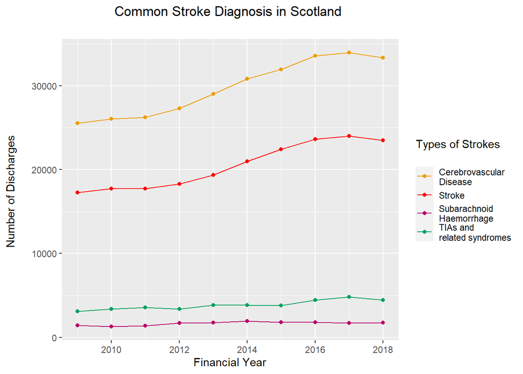

```r
health_board_stroke %>%
  filter(hb_name %in% "Scotland",
          across(admission_type:sex, ~.x=="All")) %>%
  ggplot(aes(x = financial_year,
             y = number_of_discharges,
             col = diagnosis)) +
  geom_point() +
  geom_line(aes(group = diagnosis)) +
  scale_colour_manual(values = nhs,
                      labels = c("Cerebrovascular \nDisease",
                                 "Stroke", "Subarachnoid \nHaemorrhage",
                                 "TIAs and \nrelated syndromes")) +
  labs(title = "Common Stroke Diagnosis in Scotland \n",
       x = "Financial Year",
       y = "Number of Discharges \n",
       colour = "Types of Strokes\n") +
  theme(plot.title = element_text(hjust = 0.5))
```

Cerebrovascular Disease: Group of conditions that affect blood flow and the blood vessels in the brain

Stroke: Subtype of Cerebrovascular Disease

Subarachnoid Haemorrhage: Uncommon type of stroke from burst blood vessel in the brain

TIAs and related syndromes: Temporary period of similar symptoms

From 2009/10 - 2018/19

Cerebrovascular Disease:

- 30% increase in diagnosis cases

Stroke:

- 36% increase in diagnosis cases

# 7 Differences in stroke diagnoses between different demographics

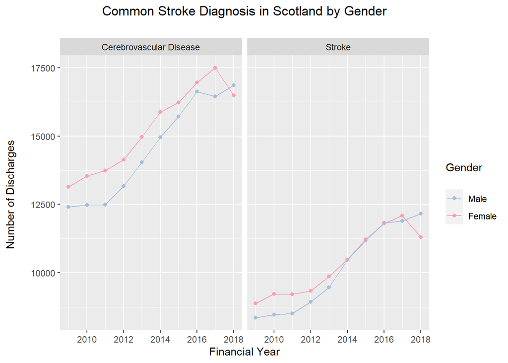

```r
health_board_stroke %>%
  filter(hb_name %in% "Scotland",
          across(admission_type:age_group, ~.x=="All"),
         sex %!in% "All",
         diagnosis %!in% c("Subarachnoid Haemorrhage",
                           "TIAs and related syndromes")) %>%
  ggplot(aes(x = financial_year,
             y = number_of_discharges,
             col = sex)) +
  geom_point() +
  geom_line(aes(group = sex)) +
  scale_colour_manual(values = pal) +
  labs(title = "Common Stroke Diagnosis in Scotland by Gender\n",
       x = "Financial Year",
       y = "Number of Discharges \n",
       colour = "Gender\n") +
  theme(plot.title = element_text(hjust = 0.5)) +
  facet_wrap(~diagnosis)
```

Focusing on the two main types of Strokes.

Both genders have similar numbers of diagnosis, with Females higher than Males.

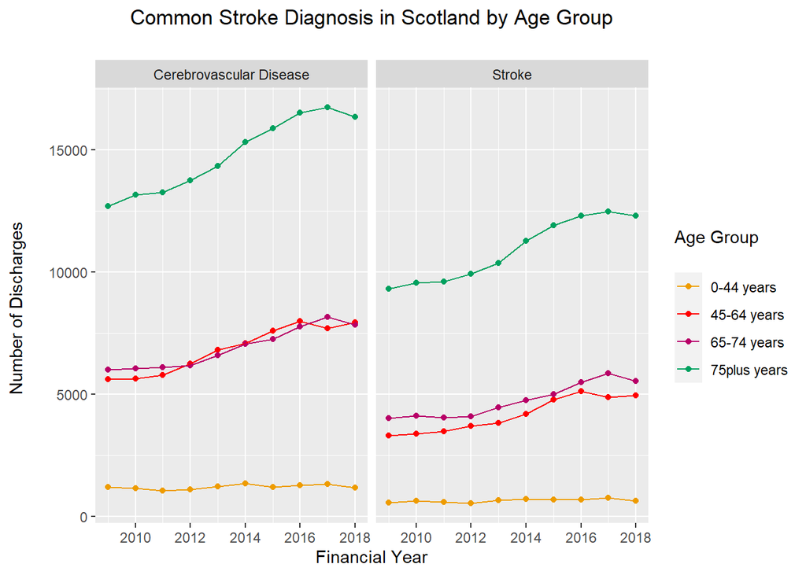

```r
health_board_stroke %>%
  filter(hb_name %in% "Scotland",
         sex %in% "All",
         admission_type %in% "All",
         age_group %!in% c("All", "under75 years"),
         diagnosis %!in% c("Subarachnoid Haemorrhage",
                           "TIAs and related syndromes")) %>%
  ggplot(aes(x = financial_year,
             y = number_of_discharges,
             col = age_group)) +
  geom_point() +
  geom_line(aes(group = age_group)) +
  scale_colour_manual(values = nhs) +
  labs(title = "Common Stroke Diagnosis in Scotland by Age Group\n",
       x = "Financial Year",
       y = "Number of Discharges \n",
       colour = "Age Group\n") +
  theme(plot.title = element_text(hjust = 0.5)) +
  facet_wrap(~diagnosis)
```

There’s a more obvious difference diagnosis rates when age is taken into account.

very few under 44 being diagnosed, an increased risk from 45-74 and a higher risk above 75 age.

# 8 Differences in stroke diagnoses between different Health Boards

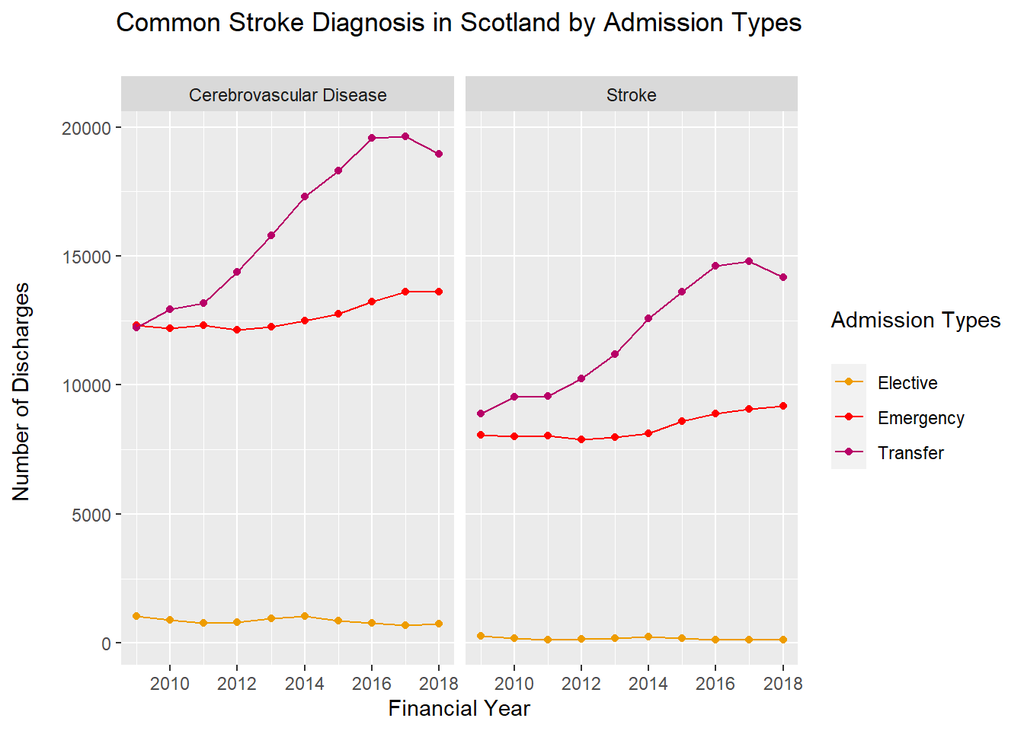

```r
health_board_stroke %>%
  filter(hb_name %in% "Scotland",
          across(age_group:sex, ~.x=="All"),
         admission_type %!in% "All",
         diagnosis %!in% c("Subarachnoid Haemorrhage",
                           "TIAs and related syndromes")) %>%
  ggplot(aes(x = financial_year,
             y = number_of_discharges,
             col = admission_type)) +
  geom_point() +
  geom_line(aes(group = admission_type)) +
  scale_colour_manual(values = nhs) +
  labs(title = "Common Stroke Diagnosis in Scotland by Admission Types\n",
       x = "Financial Year",
       y = "Number of Discharges \n",
       colour = "Admission Types\n") +
  theme(plot.title = element_text(hjust = 0.5)) +
  facet_wrap(~diagnosis)
```

High number of cases require the transfer of the patient from an Health Board to another.

Health Boards with specialist hub or more space for treatment take these extra patients.

The rate of transfer has increased 55% Cerebrovascular Disease and 59% Stroke in this time frame.

Will compare to the mortality rates later.

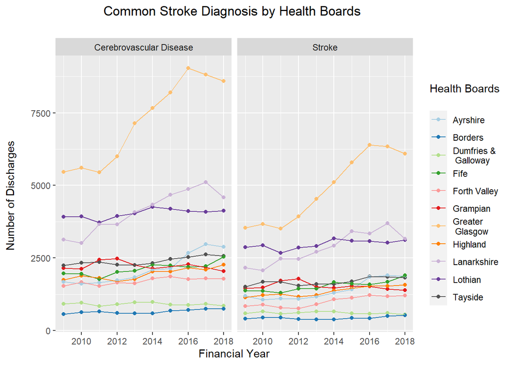

```r
health_board_stroke %>%
  filter(hb_name %!in% c("Scotland", "NHS Western Isles",
                         "NHS Orkney", "NHS Shetland"),
         across(admission_type:sex, ~.x=="All"),
         diagnosis %!in% c("Subarachnoid Haemorrhage",
                           "TIAs and related syndromes")) %>%
  ggplot(aes(x = financial_year,
             y = number_of_discharges,
             group = hb_name, col = hb_name )) +
  geom_point() +
  geom_line() +
  scale_colour_manual(values = hb,
                      labels = c("Ayrshire", "Borders", "Dumfries &\n Galloway",
                                 "Fife", "Forth Valley", "Grampian",
                                 "Greater\n Glasgow", "Highland", "Lanarkshire",
                                 "Lothian", "Tayside")) +
  labs(title = "Common Stroke Diagnosis by Health Boards \n",
       x = "Financial Year",
       y = "Number of Discharges \n",
       colour = "Health Boards\n") +
  theme(plot.title = element_text(hjust = 0.5)) +
  facet_wrap(~diagnosis)
```

Both NHS Glasgow and Lanarkshire increase coincides with patient being transfer there.

NHS Lothian and other Health Boards have similar numbers throughout, suggesting transfer where for more treatment space.

Omitted the NHS Western Isles, NHS Orkney, NHS Shetland due to them having almost no cases, transfer cases to the mainland.

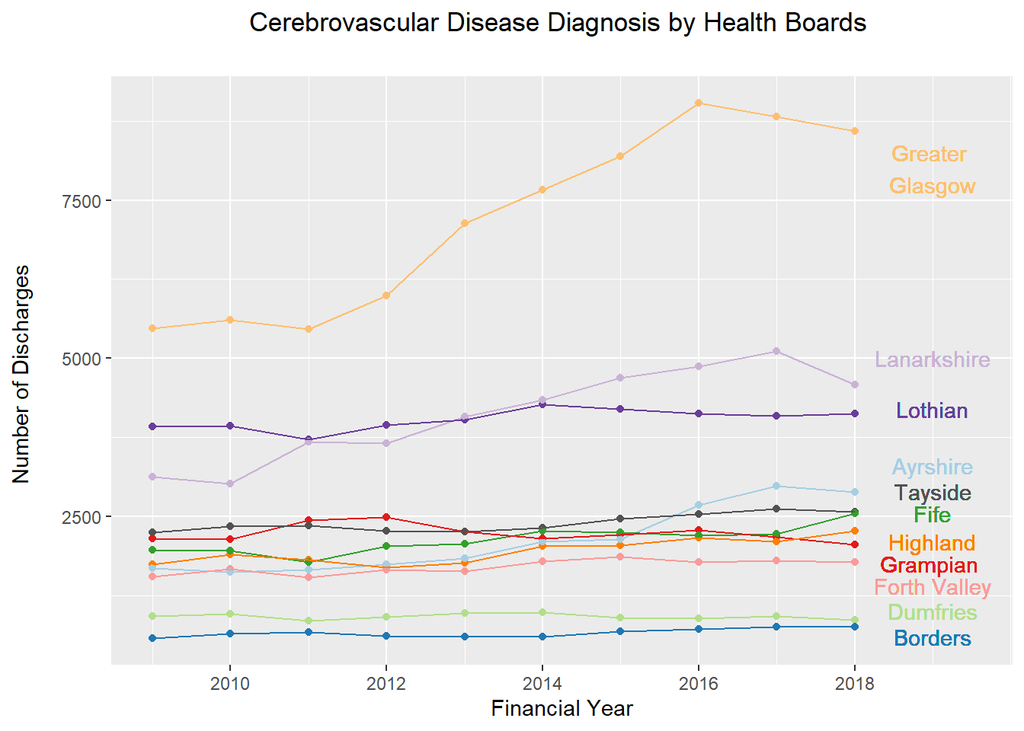

```r
health_board_stroke %>%
  filter(hb_name %!in% c("Scotland", "NHS Western Isles",
                         "NHS Orkney", "NHS Shetland"),
         across(admission_type:sex, ~.x=="All"),
         diagnosis %in% "Cerebrovascular Disease") %>%
  ggplot(aes(x = financial_year,
             y = number_of_discharges,
             group = hb_name, col = hb_name )) +
  geom_point() +
  geom_line() +
  scale_colour_manual(values = hb, guide = "none") +
  geom_text(aes(label = "Borders",
                x = 2019, y = 600), color = "#1f78b4") +
  geom_text(aes(label = "Greater \nGlasgow",
                x = 2019, y = 8000), color = "#fdbf6f") +
  geom_text(aes(label = "Dumfries",
                x = 2019, y = 1000), color = "#b2df8a") +
  geom_text(aes(label = "Lothian",
                x = 2019, y = 4200), color = "#6a3d9a") +
  geom_text(aes(label = "Lanarkshire",
                x = 2019, y = 5000), color = "#cab2d6") +
  geom_text(aes(label = "Forth Valley",
                x = 2019, y = 1400), color = "#fb9a99") +
  geom_text(aes(label = "Grampian ",
                x = 2019, y = 1750), color = "#e31a1c") +
  geom_text(aes(label = "Highland",
                x = 2019, y = 2100), color = "#ff7f00") +
  geom_text(aes(label = "Fife",
                x = 2019, y = 2550), color = "#33a02c") +
  geom_text(aes(label = "Tayside",
                x = 2019, y = 2900), color = "#525252") +
  geom_text(aes(label = "Ayrshire",
                x = 2019, y = 3300), color = "#a6cee3") +
   scale_x_continuous(limits = c(2009, 2019.5),
                      breaks = c(2010, 2012, 2014, 2016, 2018)) +
  labs(title = "Cerebrovascular Disease Diagnosis by Health Boards \n",
       x = "Financial Year",
       y = "Number of Discharges \n") +
  theme(plot.title = element_text(hjust = 0.5))
```

# 9 Differences in number of cases by health board vs by local authority

Some disparity in the data between the total cases across the local authority’s compared to the Health board.

Health board with more than one local authority.

NHS Grampian : Aberdeen, Aberdeenshire and Moray.

NHS Tayside : Angus, the City of Dundee and Perth and Kinross.

NHS Forth Valley : Clackmannanshire, Falkirk and Stirling

NHS Ayrshire and Arran : North Ayrshire South Ayrshire East Ayrshire

NHS Lothian : City of Edinburgh, East Lothian, Midlothian and West Lothian

NHS Greater Glasgow and Clyde : City of Glasgow, East Dunbartonshire, East Renfrewshire, Inverclyde, Renfrewshire and West Dunbartonshire.

NHS Lanarkshire : North Lanarkshire and South Lanarkshire

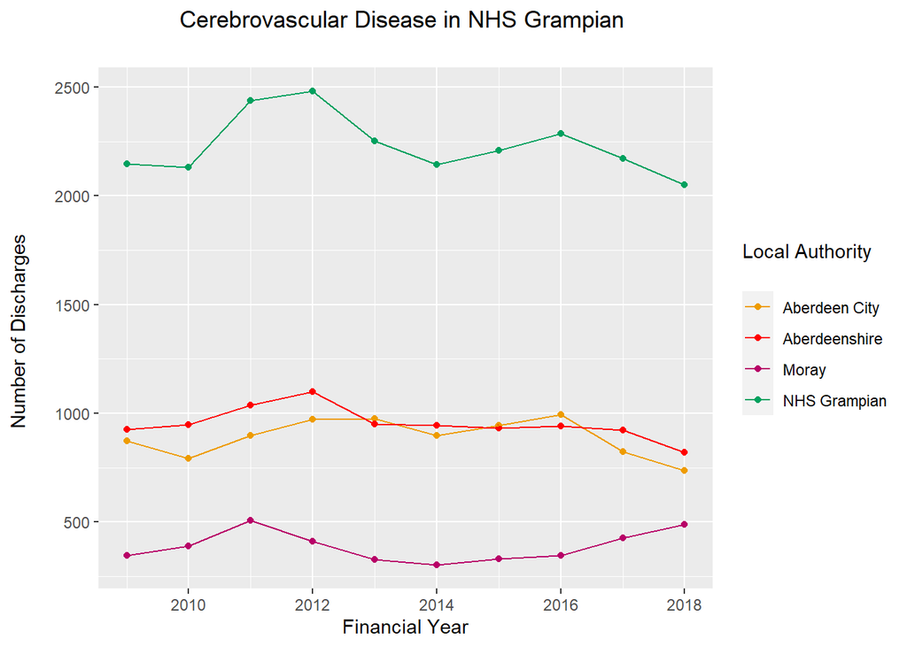

```r
grampian <- health_board_stroke %>%
  filter(hb_name %in% "NHS Grampian",
         across(admission_type:sex, ~.x=="All"),
         diagnosis %in% "Cerebrovascular Disease") %>%
  rename(council_name = hb_name)


nhs_grampian <-  bind_rows(council_stroke, grampian)

nhs_grampian %>%
   filter(council_name %in% c("Aberdeen City",
                              "Aberdeenshire", "Moray",
                              "NHS Grampian"),
         across(admission_type:sex, ~.x=="All"),
         diagnosis %in% "Cerebrovascular Disease") %>%
  ggplot(aes(x = financial_year,
             y = number_of_discharges)) +
  geom_point(aes(group = council_name, col = council_name)) +
  geom_line(aes(group = council_name, col = council_name)) +
    scale_colour_manual(values = nhs,
                      labels = c("Aberdeen City",
                                 "Aberdeenshire", "Moray",
                                 "NHS Grampian")) +
  labs(title = "Cerebrovascular Disease in NHS Grampian \n",
       x = "Financial Year",
       y = "Number of Discharges \n",
       colour = "Local Authority\n") +
  theme(plot.title = element_text(hjust = 0.5))
```

```r
nhs_grampian %>%
   filter(council_name %in% c("Aberdeen City",
                        "Aberdeenshire", "Moray"),
         across(admission_type:sex, ~.x=="All"),
         diagnosis %in% "Cerebrovascular Disease") %>%
  group_by(financial_year) %>%
  summarise(sum_of_discharges = sum(number_of_discharges))
```

| financial_year | sum_of_discharges |
| --- | --- |
| 2009 | 2147 |
| 2010 | 2131 |
| 2011 | 2439 |
| 2012 | 2482 |
| 2013 | 2252 |
| 2014 | 2144 |
| 2015 | 2208 |
| 2016 | 2281 |
| 2017 | 2172 |
| 2018 | 2046 |

```r
health_board_stroke %>%
  filter(hb_name %in% "NHS Grampian",
         across(admission_type:sex, ~.x=="All"),
         diagnosis %in% "Cerebrovascular Disease") %>%
  select(hb_name, financial_year, number_of_discharges)
```

| hb_name | financial_year | number_of_discharges |
| --- | --- | --- |
| NHS Grampian | 2009 | 2147 |
| NHS Grampian | 2010 | 2131 |
| NHS Grampian | 2011 | 2439 |
| NHS Grampian | 2012 | 2482 |
| NHS Grampian | 2013 | 2252 |
| NHS Grampian | 2014 | 2144 |
| NHS Grampian | 2015 | 2208 |
| NHS Grampian | 2016 | 2285 |
| NHS Grampian | 2017 | 2172 |
| NHS Grampian | 2018 | 2052 |

For Cerebrovascular Disease NHS Grampian has an extra 6, 0.3% in 2018/19 compared to the local authority’s

```r
nhs_grampian %>%
   filter(council_name %in% c("Aberdeen City",
                        "Aberdeenshire", "Moray"),
         across(admission_type:sex, ~.x=="All")) %>%
  group_by(financial_year) %>%
  summarise(sum_of_discharges = sum(number_of_discharges))
```

| financial_year | sum_of_discharges |
| --- | --- |
| 2009 | 3948 |
| 2010 | 4004 |
| 2011 | 4618 |
| 2012 | 4658 |
| 2013 | 4135 |
| 2014 | 3983 |
| 2015 | 4146 |
| 2016 | 4273 |
| 2017 | 4084 |
| 2018 | 3825 |

```r
health_board_stroke %>%
  filter(hb_name %in% "NHS Grampian",
         across(admission_type:sex, ~.x=="All")) %>%
  group_by(financial_year) %>%
  summarise(sum_of_discharges = sum(number_of_discharges))
```

| financial_year | sum_of_discharges |
| --- | --- |
| 2009 | 3948 |
| 2010 | 4004 |
| 2011 | 4618 |
| 2012 | 4658 |
| 2013 | 4135 |
| 2014 | 3983 |
| 2015 | 4146 |
| 2016 | 4281 |
| 2017 | 4084 |
| 2018 | 3831 |

NHS Grampian across all the four types of strokes has an extra 8, 0.2% in 2016/17 and an extra 6, 0.2% in 2018/19 compared to the local authority’s

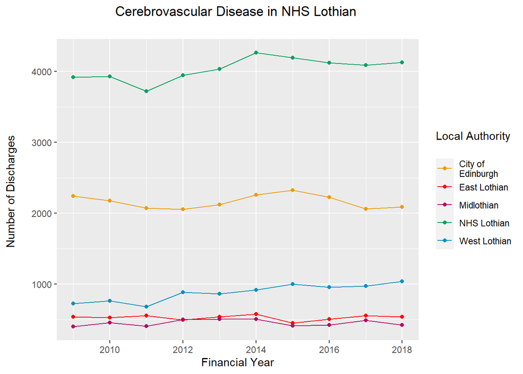

```r
lothian <- health_board_stroke %>%
  filter(hb_name %in% "NHS Lothian",
         across(admission_type:sex, ~.x=="All"),
         diagnosis %in% "Cerebrovascular Disease") %>%
  rename(council_name = hb_name)


nhs_lothian <-  bind_rows(council_stroke, lothian)

nhs_lothian %>%
   filter(council_name %in% c("City of Edinburgh",
                        "East Lothian", "Midlothian",
                        "West Lothian", "NHS Lothian"),
         across(admission_type:sex, ~.x=="All"),
         diagnosis %in% "Cerebrovascular Disease") %>%
  ggplot(aes(x = financial_year,
             y = number_of_discharges)) +
  geom_point(aes(group = council_name, col = council_name)) +
  geom_line(aes(group = council_name, col = council_name)) +
  scale_colour_manual(values = nhs,
                      labels = c("City of \nEdinburgh",
                                 "East Lothian", "Midlothian",
                                 "NHS Lothian", "West Lothian")) +
  labs(title = "Cerebrovascular Disease in NHS Lothian \n",
       x = "Financial Year",
       y = "Number of Discharges \n",
       colour = "Local Authority\n") +
  theme(plot.title = element_text(hjust = 0.5))
```

```r
nhs_lothian %>%
   filter(council_name %in% c("City of Edinburgh",
                        "East Lothian", "Midlothian",
                        "West Lothian"),
         across(admission_type:sex, ~.x=="All"),
         diagnosis %in% "Cerebrovascular Disease") %>%
  group_by(financial_year) %>%
  summarise(sum_of_discharges = sum(number_of_discharges))
```

| financial_year | sum_of_discharges |
| --- | --- |
| 2009 | 3915 |
| 2010 | 3928 |
| 2011 | 3718 |
| 2012 | 3943 |
| 2013 | 4031 |
| 2014 | 4264 |
| 2015 | 4193 |
| 2016 | 4118 |
| 2017 | 4082 |
| 2018 | 4101 |

```r
health_board_stroke %>%
  filter(hb_name %in% "NHS Lothian",
         across(admission_type:sex, ~.x=="All"),
         diagnosis %in% "Cerebrovascular Disease") %>%
  select(hb_name, financial_year, number_of_discharges)
```

| hb_name | financial_year | number_of_discharges |
| --- | --- | --- |
| NHS Lothian | 2009 | 3915 |
| NHS Lothian | 2010 | 3928 |
| NHS Lothian | 2011 | 3718 |
| NHS Lothian | 2012 | 3943 |
| NHS Lothian | 2013 | 4031 |
| NHS Lothian | 2014 | 4264 |
| NHS Lothian | 2015 | 4193 |
| NHS Lothian | 2016 | 4118 |
| NHS Lothian | 2017 | 4087 |
| NHS Lothian | 2018 | 4125 |

For Cerebrovascular Disease NHS Lothian has an extra 5, 0.1% in 2017/18 and an extra 24, 0.6% in 2018/19 compared to the local authority’s

```r
nhs_lothian %>%
   filter(council_name %in% c("City of Edinburgh",
                        "East Lothian", "Midlothian",
                        "West Lothian"),
         across(admission_type:sex, ~.x=="All")) %>%
  group_by(financial_year) %>%
  summarise(sum_of_discharges = sum(number_of_discharges))
```

| financial_year | sum_of_discharges |
| --- | --- |
| 2009 | 7349 |
| 2010 | 7455 |
| 2011 | 7055 |
| 2012 | 7503 |
| 2013 | 7647 |
| 2014 | 8168 |
| 2015 | 8010 |
| 2016 | 7867 |
| 2017 | 7814 |
| 2018 | 7868 |

```r
health_board_stroke %>%
  filter(hb_name %in% "NHS Lothian",
         across(admission_type:sex, ~.x=="All")) %>%
  group_by(financial_year) %>%
  summarise(sum_of_discharges = sum(number_of_discharges))
```

| financial_year | sum_of_discharges |
| --- | --- |
| 2009 | 7349 |
| 2010 | 7455 |
| 2011 | 7055 |
| 2012 | 7503 |
| 2013 | 7647 |
| 2014 | 8168 |
| 2015 | 8010 |
| 2016 | 7867 |
| 2017 | 7822 |
| 2018 | 7913 |

NHS Lothian across all the four types of strokes has an extra 8, 0.1% in 2017/18 and an extra 45, 0.6% in 2018/19 compared to the local authority’s

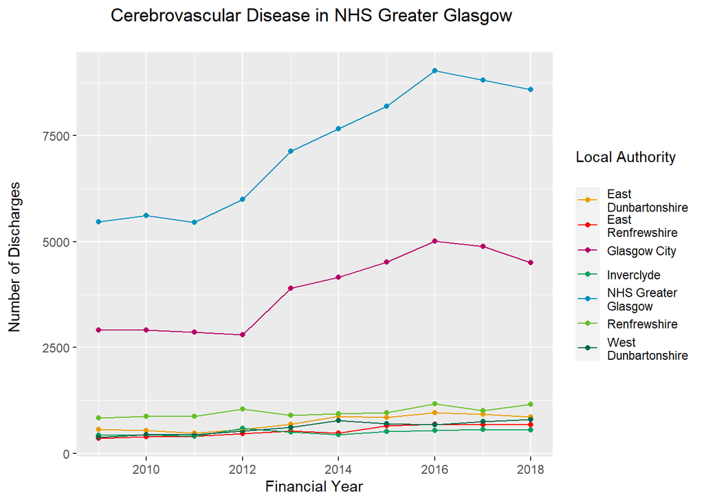

```r
glasgow <- health_board_stroke %>%
  filter(hb_name %in% "NHS Greater Glasgow and Clyde",
         across(admission_type:sex, ~.x=="All"),
         diagnosis %in% "Cerebrovascular Disease") %>%
  rename(council_name = hb_name)


nhs_glasgow <-  bind_rows(council_stroke, glasgow)

nhs_glasgow %>%
   filter(council_name %in% c("Glasgow City",
                        "East Dunbartonshire", "East Renfrewshire",
                        "Inverclyde", "Renfrewshire", "West Dunbartonshire",
                        "NHS Greater Glasgow and Clyde"),
         across(admission_type:sex, ~.x=="All"),
         diagnosis %in% "Cerebrovascular Disease") %>%
  ggplot(aes(x = financial_year,
             y = number_of_discharges)) +
  geom_point(aes(group = council_name, col = council_name)) +
  geom_line(aes(group = council_name, col = council_name)) +
  scale_colour_manual(values = nhs,
                      labels = c("East \nDunbartonshire", "East \nRenfrewshire",
                                 "Glasgow City", "Inverclyde",
                                 "NHS Greater \nGlasgow ",
                                 "Renfrewshire", "West \nDunbartonshire")) +
  labs(title = "Cerebrovascular Disease in NHS Greater Glasgow \n",
       x = "Financial Year",
       y = "Number of Discharges \n",
       colour = "Local Authority\n") +
  theme(plot.title = element_text(hjust = 0.5))
```

```r
nhs_glasgow %>%
   filter(council_name %in% c("Glasgow City",
                        "East Dunbartonshire", "East Renfrewshire",
                        "Inverclyde", "Renfrewshire", "West Dunbartonshire"),
         across(admission_type:sex, ~.x=="All")) %>%
  group_by(financial_year) %>%
  summarise(sum_of_discharges = sum(number_of_discharges))
```

| financial_year | sum_of_discharges |
| --- | --- |
| 2009 | 10070 |
| 2010 | 10379 |
| 2011 | 10172 |
| 2012 | 11082 |
| 2013 | 13166 |
| 2014 | 14224 |
| 2015 | 15322 |
| 2016 | 17090 |
| 2017 | 16681 |
| 2018 | 16120 |

```r
health_board_stroke %>%
  filter(hb_name %in% "NHS Greater Glasgow and Clyde",
         across(admission_type:sex, ~.x=="All")) %>%
  group_by(financial_year) %>%
  summarise(sum_of_discharges = sum(number_of_discharges))
```

| financial_year | sum_of_discharges |
| --- | --- |
| 2009 | 10070 |
| 2010 | 10379 |
| 2011 | 10172 |
| 2012 | 11082 |
| 2013 | 13172 |
| 2014 | 14224 |
| 2015 | 15326 |
| 2016 | 17093 |
| 2017 | 16695 |
| 2018 | 16206 |

NHS Greater Glasgow and Clyde across all the four types of strokes has an extra 3, 0.02% in 2016/17, an extra 14, 0.08% in 2017/18 and an extra 86, 0.5% in 2018/19 compared to the local authority’s

Very small number of cases and predominantly in the last few years of the timeframe.

# 10 Differences in mortality rates for different types of stroke

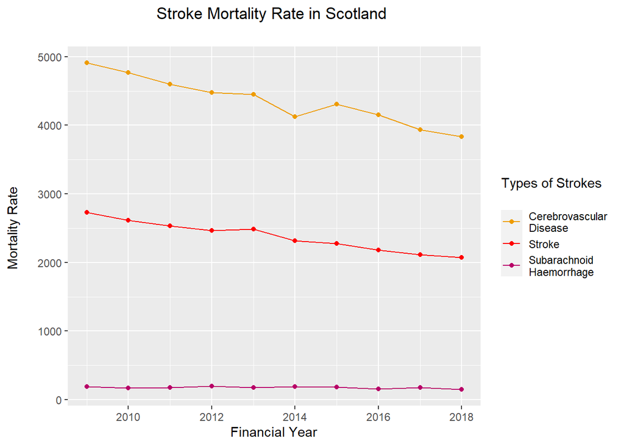

```r
health_board_mortality %>%
  filter(hb_name %in% "Scotland",
          across(age_group:sex, ~.x=="All")) %>%
  ggplot(aes(x = year,
             y = number_of_deaths,
             col = diagnosis)) +
  geom_point() +
  geom_line(aes(group = diagnosis)) +
  scale_colour_manual(values = nhs,
                      labels = c("Cerebrovascular \nDisease", "Stroke",
                                 "Subarachnoid \nHaemorrhage")) +
  labs(title = "Stroke Mortality Rate in Scotland \n",
       x = "Financial Year",
       y = "Mortality Rate \n",
       colour = "Types of Strokes\n") +
  theme(plot.title = element_text(hjust = 0.5))
```

Cerebrovascular Disease:  
Mortality Rate down 22%

- 19% of the diagnosis in 2009/10
- 11% of the diagnosis in 2018/19

Stroke:  
Mortality Rate down 24%

- 15% of the diagnosis in 2009/10
- 8% of the diagnosis in 2018/19

Subarachnoid Haemorrhage:  
Mortality Rate down 22%

- 13% of the diagnosis in 2009/10
- 8% of the diagnosis in 2018/19

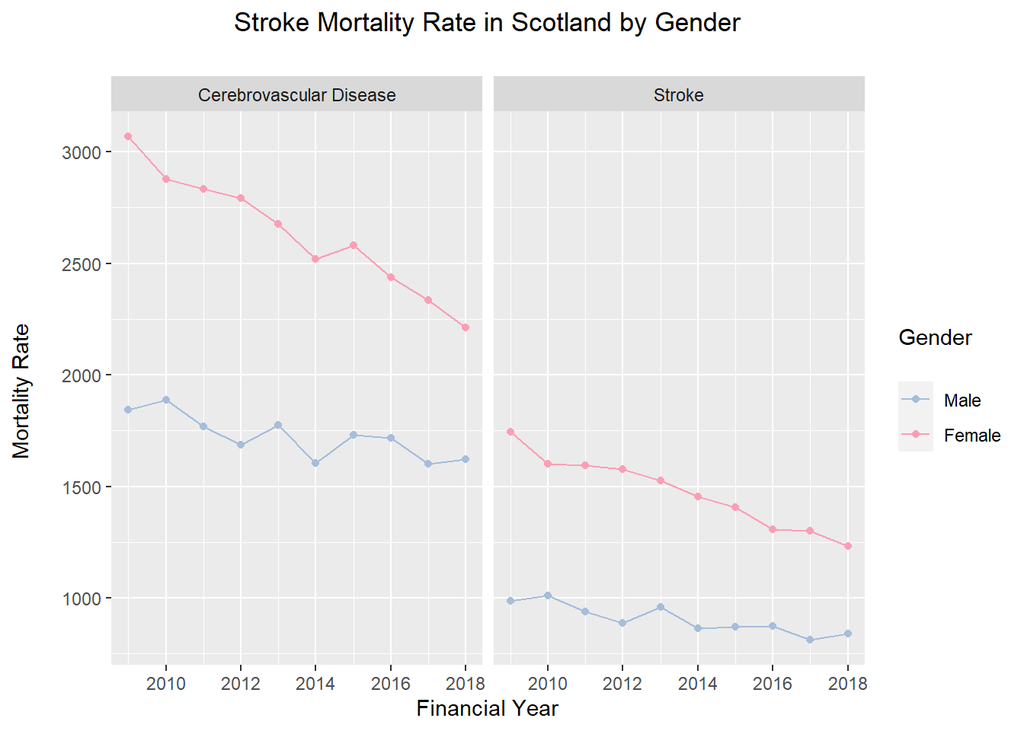

```r
health_board_mortality %>%
  filter(hb_name %in% "Scotland",
          across(age_group, ~.x=="All"),
         sex %!in% "All",
         diagnosis %!in% c("Subarachnoid Haemorrhage",
                           "TIAs and related syndromes")) %>%
  ggplot(aes(x = year,
             y = number_of_deaths,
             col = sex)) +
  geom_point() +
  geom_line(aes(group = sex)) +
  scale_colour_manual(values = pal) +
  labs(title = "Stroke Mortality Rate in Scotland by Gender\n",
       x = "Financial Year",
       y = "Mortality Rate \n",
       colour = "Gender\n") +
  theme(plot.title = element_text(hjust = 0.5)) +
  facet_wrap(~diagnosis)
```

Cerebrovascular Disease:  
Female:

- Mortality Rate down 28%

Male:

- Mortality Rate down 11%

Stroke:  
Female:

- Mortality Rate down 29%

Male:

- Mortality Rate down 14%

While genders have similar numbers of diagnosis, Female make a high number of the deaths.

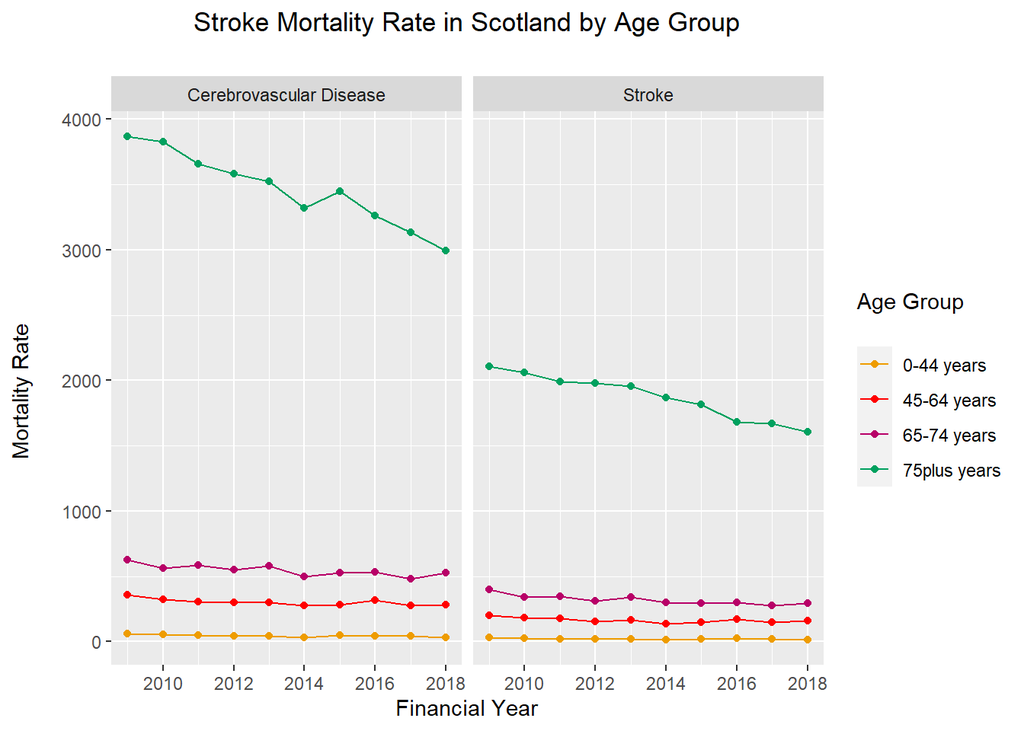

```r
health_board_mortality %>%
  filter(hb_name %in% "Scotland",
         sex %in% "All",
         age_group %!in% c("All", "under75 years"),
         diagnosis %!in% c("Subarachnoid Haemorrhage",
                           "TIAs and related syndromes")) %>%
  ggplot(aes(x = year,
             y = number_of_deaths,
             col = age_group)) +
  geom_point() +
  geom_line(aes(group = age_group)) +
  scale_colour_manual(values = nhs) +
  labs(title = "Stroke Mortality Rate in Scotland by Age Group\n",
       x = "Financial Year",
       y = "Mortality Rate \n",
       colour = "Age Group\n") +
  theme(plot.title = element_text(hjust = 0.5)) +
  facet_wrap(~diagnosis)
```

Predominantly the deaths are from patients over 75 years old. The Mortality Rate of has followed the 22% and 24% decrease respectively.

The other age groups show between 15-26% decrease

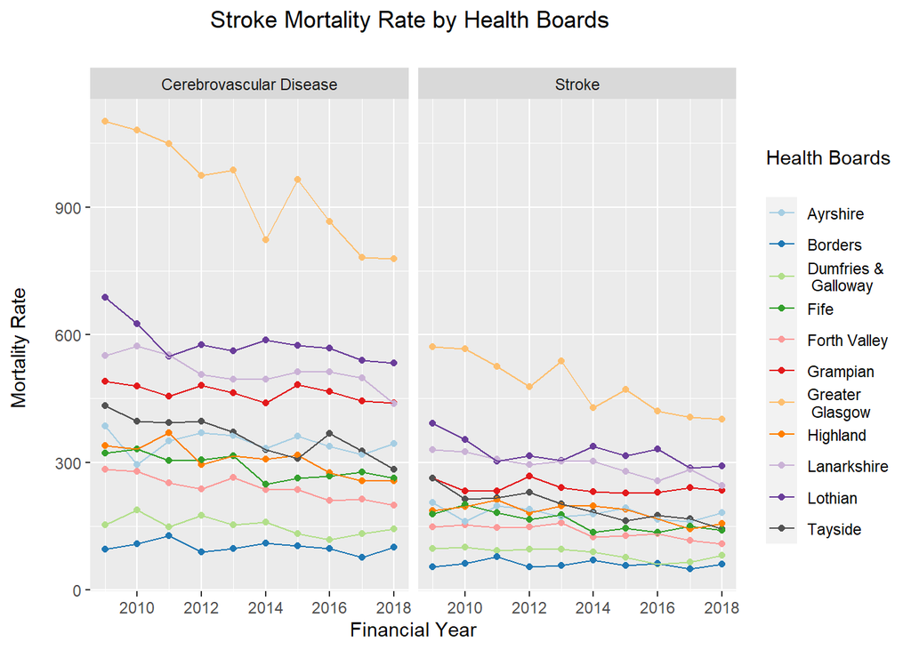

```r
health_board_mortality %>%
  filter(hb_name %!in% c("Scotland", "NHS Western Isles",
                         "NHS Orkney", "NHS Shetland"),
         across(age_group:sex, ~.x=="All"),
         diagnosis %!in% c("Subarachnoid Haemorrhage",
                           "TIAs and related syndromes")) %>%
  ggplot(aes(x = year,
             y = number_of_deaths,
             group = hb_name, col = hb_name )) +
  geom_point() +
  geom_line() +
  scale_colour_manual(values = hb,
                      labels = c("Ayrshire", "Borders", "Dumfries &\n Galloway",
                                 "Fife", "Forth Valley", "Grampian",
                                 "Greater\n Glasgow", "Highland", "Lanarkshire",
                                 "Lothian", "Tayside")) +
  labs(title = "Stroke Mortality Rate by Health Boards \n",
       x = "Financial Year",
       y = "Mortality Rate \n",
       colour = "Health Boards\n") +
  theme(plot.title = element_text(hjust = 0.5)) +
  facet_wrap(~diagnosis)
```

NHS Glasgow has the highest Mortality numbers.

The other Health Boards follow a similar order to the diagnosis data, just NHS Grampian has grouped with Lothian and Lanarkshire.

All the island Health Boards had no Mortality data due to them having transfer cases to the mainland.

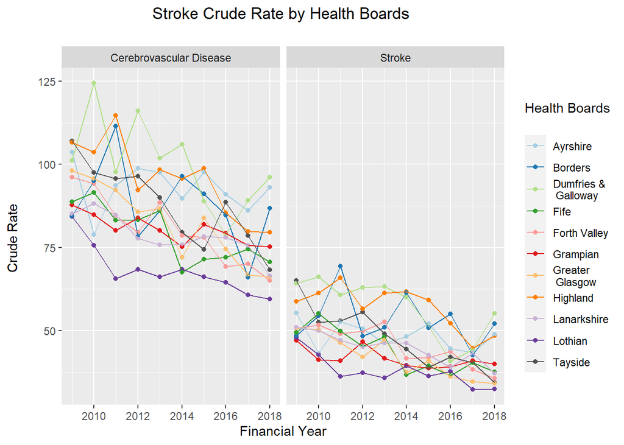

```r
health_board_mortality %>%
  filter(hb_name %!in% c("Scotland", "NHS Western Isles",
                         "NHS Orkney", "NHS Shetland"),
         across(age_group:sex, ~.x=="All"),
         diagnosis %!in% c("Subarachnoid Haemorrhage",
                           "TIAs and related syndromes")) %>%
  ggplot(aes(x = year,
             y = crude_rate,
             group = hb_name, col = hb_name )) +
  geom_point() +
  geom_line() +
  scale_colour_manual(values = hb,
                      labels = c("Ayrshire", "Borders", "Dumfries &\n Galloway",
                                 "Fife", "Forth Valley", "Grampian",
                                 "Greater\n Glasgow", "Highland", "Lanarkshire",
                                 "Lothian", "Tayside")) +
  labs(title = "Stroke Crude Rate by Health Boards \n",
       x = "Financial Year",
       y = "Crude Rate \n",
       colour = "Health Boards\n") +
  theme(plot.title = element_text(hjust = 0.5)) +
  facet_wrap(~diagnosis)
```

The crude rate is set at per 100,000 population, this allows for fairer comparisons between geographies with different population totals.

NHS Lothian has the best proportion for both types of Strokes.

# 11 Proposed Focus Areas

### 11.0.1 Rural Focus

- Focus on areas with higher mortality proportion to their population: NHS Dumfries & Galloway, Borders and Highland

### 11.0.2 Transfer Focus

- Continue to focus on treatment hubs with higher number of specialist together: NHS Glasgow, Lothian, Lanarkshire and possibly include Grampian

### 11.0.3 Gender Focus

- Focus on preventative measures primarily Female.
- Male patients may have succumbed to other health issues, should be included in preventative measures

### 11.0.4 Preventative Age Focus

- Encourage throughout adulthood: healthy diet, exercise regularly, and avoid smoking and drinking too much alcohol.